# Instacart Basket Analysis

### Contents-

0.1 Importing Libraries

0.2 Importing Data

0.3 Addressing PII

0.4 Creating Flags and Profiles

0.5 Visualizations

0.6 Aggregation

0.7 Crosstabs

0.8 Exporting Visualizations

## 0.1 Importing Libraries

```python
import pandas as pd
import numpy as np
import os
import matplotlib.pyplot as plt
import seaborn as sns
import scipy
```

## 0.2 Importing Data

```python
# Establishing path

path = r'/Users/Kate/Documents/Instacart Basket Analysis'
```

```python
# Importing data

df_all = pd.read_pickle(os.path.join(path, '02 Data', 'Prepared Data', 'orders_products_customers_final.pkl'))
```

## 0.3 Addressing PII

### 2. Consider any security implications that might exist for this new data. You’ll need to address any PII data in the data before continuing your analysis.

I have already taken this into consideration. During the last exercise, I removed the columns containing customers' first and last names. This data is not necessary to the project anyway, so it will have no impact on the outcome and findings.

## 0.4 Creating Flags and Profiles

### 3. The Instacart officers are interested in comparing customer behavior in different geographic areas. Create a regional segmentation of the data. You’ll need to create a “Region” column based on the “State” column from your customers data set.

Use the region information in this Wikipedia article to create your column (you only need to create regions, not divisions).

```python
#creating a new column for regions based on 'state'

def get_region(state, region):
    if state in region['Northeast']:
        return 'Northeast'
    elif state in region['Midwest']:
        return 'Midwest'
    elif state in region['South']:
        return 'South'
    elif state in region['West']:
        return 'West'
    else:
        return None

Northeast = ['Maine', 'New Hampshire', 'Vermont', 'Massachusetts', 'Rhode Island', 'Connecticut', 'New York', 'Pennsylvania', 'New Jersey']
Midwest = ['Wisconsin', 'Michigan', 'Illinois', 'Indiana', 'Ohio', 'North Dakota', 'South Dakota', 'Nebraska', 'Kansas', 'Minnesota', 'Iowa', 'Missouri']
South = ['Delaware', 'Maryland', 'DC', 'Virginia', 'West Virginia', 'North Carolina', 'South Carolina', 'Georgia', 'Florida', 'Kentucky', 'Tennessee', 'Mississippi', 'Alabama','Oklahoma', 'Texas', 'Arkansas', 'Louisiana']
West = ['Idaho', 'Montana', 'Wyoming', 'Nevada', 'Utah', 'Colorado', 'Arizona', 'New Mexico', 'Alaska', 'Washington', 'Oregon', 'California', 'Hawaii',]

region = {'Northeast': Northeast, 'Midwest': Midwest, 'South': South, 'West': West}
df_all['region'] = df_all['state'].apply(get_region, args=(region,))
```

```python
df_all.head()
```

|  | order_id | user_id | order_number | orders_day_of_week | order_hour_of_day | days_since_prior_order | product_id | add_to_cart_order | reordered | product_name | ... | max_order | loyalty_flag | gender | state | age | date_joined | dependants | family_status | income | region |
| --- | --- | --- | --- | --- | --- | --- | --- | --- | --- | --- | --- | --- | --- | --- | --- | --- | --- | --- | --- | --- | --- |
| 0 | 2539329 | 1 | 1 | 2 | 8 | NaN | 196 | 1 | 0 | Soda | ... | 10 | New customer | Female | Alabama | 31 | 2/17/2019 | 3 | married | 40423 | South |
| 1 | 2398795 | 1 | 2 | 3 | 7 | 15.0 | 196 | 1 | 1 | Soda | ... | 10 | New customer | Female | Alabama | 31 | 2/17/2019 | 3 | married | 40423 | South |
| 2 | 473747 | 1 | 3 | 3 | 12 | 21.0 | 196 | 1 | 1 | Soda | ... | 10 | New customer | Female | Alabama | 31 | 2/17/2019 | 3 | married | 40423 | South |
| 3 | 2254736 | 1 | 4 | 4 | 7 | 29.0 | 196 | 1 | 1 | Soda | ... | 10 | New customer | Female | Alabama | 31 | 2/17/2019 | 3 | married | 40423 | South |
| 4 | 431534 | 1 | 5 | 4 | 15 | 28.0 | 196 | 1 | 1 | Soda | ... | 10 | New customer | Female | Alabama | 31 | 2/17/2019 | 3 | married | 40423 | South |

5 rows × 27 columns

Determine whether there’s a difference in spending habits between the different U.S. regions. (Hint: You can do this by crossing the variable you just created with the spending flag.)

```python
df_all['max_order']
```

```
0           10
1           10
2           10
3           10
4           10
            ..
32404854    26
32404855     4
32404856     4
32404857     4
32404858     4
Name: max_order, Length: 32404859, dtype: int64
```

```python
df_all['max_order'].describe()
```

```
count    3.240486e+07
mean     3.305217e+01
std      2.515525e+01
min      1.000000e+00
25%      1.300000e+01
50%      2.600000e+01
75%      4.700000e+01
max      9.900000e+01
Name: max_order, dtype: float64
```

```python
# Creating a spending flag

df_all.loc[df_all['max_order'] > 9, 'spending_loc'] = 'High-spender'
```

```python
df_all.loc[(df_all['max_order'] <= 9) & (df_all['max_order'] > 5), 'spending_loc'] = 'Mid-range-spender'
```

```python
df_all.loc[df_all['max_order'] < 5, 'spending_loc'] = 'Low-spender'
```

```python
# Checking counts

df_all['spending_loc'].value_counts(dropna = False)
```

```
High-spender         26933993
Mid-range-spender     3237431
Low-spender           1440295
NaN                    793140
Name: spending_loc, dtype: int64
```

```python
df_all.head()
```

|  | order_id | user_id | order_number | orders_day_of_week | order_hour_of_day | days_since_prior_order | product_id | add_to_cart_order | reordered | product_name | ... | loyalty_flag | gender | state | age | date_joined | dependants | family_status | income | region | spending_loc |
| --- | --- | --- | --- | --- | --- | --- | --- | --- | --- | --- | --- | --- | --- | --- | --- | --- | --- | --- | --- | --- | --- |
| 0 | 2539329 | 1 | 1 | 2 | 8 | NaN | 196 | 1 | 0 | Soda | ... | New customer | Female | Alabama | 31 | 2/17/2019 | 3 | married | 40423 | South | High-spender |
| 1 | 2398795 | 1 | 2 | 3 | 7 | 15.0 | 196 | 1 | 1 | Soda | ... | New customer | Female | Alabama | 31 | 2/17/2019 | 3 | married | 40423 | South | High-spender |
| 2 | 473747 | 1 | 3 | 3 | 12 | 21.0 | 196 | 1 | 1 | Soda | ... | New customer | Female | Alabama | 31 | 2/17/2019 | 3 | married | 40423 | South | High-spender |
| 3 | 2254736 | 1 | 4 | 4 | 7 | 29.0 | 196 | 1 | 1 | Soda | ... | New customer | Female | Alabama | 31 | 2/17/2019 | 3 | married | 40423 | South | High-spender |
| 4 | 431534 | 1 | 5 | 4 | 15 | 28.0 | 196 | 1 | 1 | Soda | ... | New customer | Female | Alabama | 31 | 2/17/2019 | 3 | married | 40423 | South | High-spender |

5 rows × 28 columns

```python
# Creating a crosstab

crosstab = pd.crosstab(df_all['region'], df_all['spending_loc'], dropna = False)
```

```python
crosstab.to_clipboard()
```

Results in Excel

### 4.The Instacart CFO isn’t interested in customers who don’t generate much revenue for the app. Create an exclusion flag for low-activity customers (customers with less than 5 orders) and exclude them from the data. Make sure you export this sample.

```python
# Creating a new df excluding low spenders

df_all_2 = df_all[~df_all['spending_loc'].fillna('').str.contains('Low-spender')]
```

```python
df_all_2.shape
```

```
(30964564, 28)
```

```python
df_all_2.head()
```

|  | order_id | user_id | order_number | orders_day_of_week | order_hour_of_day | days_since_prior_order | product_id | add_to_cart_order | reordered | product_name | ... | loyalty_flag | gender | state | age | date_joined | dependants | family_status | income | region | spending_loc |
| --- | --- | --- | --- | --- | --- | --- | --- | --- | --- | --- | --- | --- | --- | --- | --- | --- | --- | --- | --- | --- | --- |
| 0 | 2539329 | 1 | 1 | 2 | 8 | NaN | 196 | 1 | 0 | Soda | ... | New customer | Female | Alabama | 31 | 2/17/2019 | 3 | married | 40423 | South | High-spender |
| 1 | 2398795 | 1 | 2 | 3 | 7 | 15.0 | 196 | 1 | 1 | Soda | ... | New customer | Female | Alabama | 31 | 2/17/2019 | 3 | married | 40423 | South | High-spender |
| 2 | 473747 | 1 | 3 | 3 | 12 | 21.0 | 196 | 1 | 1 | Soda | ... | New customer | Female | Alabama | 31 | 2/17/2019 | 3 | married | 40423 | South | High-spender |
| 3 | 2254736 | 1 | 4 | 4 | 7 | 29.0 | 196 | 1 | 1 | Soda | ... | New customer | Female | Alabama | 31 | 2/17/2019 | 3 | married | 40423 | South | High-spender |
| 4 | 431534 | 1 | 5 | 4 | 15 | 28.0 | 196 | 1 | 1 | Soda | ... | New customer | Female | Alabama | 31 | 2/17/2019 | 3 | married | 40423 | South | High-spender |

5 rows × 28 columns

```python
# Renaming 'spending_loc'

df_all.rename(columns = {'spending_loc' : 'spending_activity'}, inplace = True)
```

```python
#Checking

df_all_2.head()
```

|  | order_id | user_id | order_number | orders_day_of_week | order_hour_of_day | days_since_prior_order | product_id | add_to_cart_order | reordered | product_name | ... | loyalty_flag | gender | state | age | date_joined | dependants | family_status | income | region | spending_loc |
| --- | --- | --- | --- | --- | --- | --- | --- | --- | --- | --- | --- | --- | --- | --- | --- | --- | --- | --- | --- | --- | --- |
| 0 | 2539329 | 1 | 1 | 2 | 8 | NaN | 196 | 1 | 0 | Soda | ... | New customer | Female | Alabama | 31 | 2/17/2019 | 3 | married | 40423 | South | High-spender |
| 1 | 2398795 | 1 | 2 | 3 | 7 | 15.0 | 196 | 1 | 1 | Soda | ... | New customer | Female | Alabama | 31 | 2/17/2019 | 3 | married | 40423 | South | High-spender |
| 2 | 473747 | 1 | 3 | 3 | 12 | 21.0 | 196 | 1 | 1 | Soda | ... | New customer | Female | Alabama | 31 | 2/17/2019 | 3 | married | 40423 | South | High-spender |
| 3 | 2254736 | 1 | 4 | 4 | 7 | 29.0 | 196 | 1 | 1 | Soda | ... | New customer | Female | Alabama | 31 | 2/17/2019 | 3 | married | 40423 | South | High-spender |
| 4 | 431534 | 1 | 5 | 4 | 15 | 28.0 | 196 | 1 | 1 | Soda | ... | New customer | Female | Alabama | 31 | 2/17/2019 | 3 | married | 40423 | South | High-spender |

5 rows × 28 columns

```python
# Export to pickle
df_all_2.to_pickle(os.path.join(path, '02 Data', 'Prepared Data', 'all_merged_mid_and_high_spenders.pkl'))
```

### 5. The marketing and business strategy units at Instacart want to create more-relevant marketing strategies for different products and are, thus, curious about customer profiling in their database.

### Create a profiling variable based on age, income, certain goods in the “department_id” column, and number of dependents. You might also use the “orders_day_of_the_week” and “order_hour_of_day” columns if you can think of a way they would impact customer profiles.

### (Hint: As an example, try thinking of what characteristics would lead you to the profile “Single adult” or “Young parent.”)

I will be using df_all_2 from now on since the CFO is not interested in low-activity customers. df_all_2 excludes these customers.

#### 5.1. Age Profiling

```python
# gathering info about 'age' column

df_all_2.age.describe()
```

```
count    3.096456e+07
mean     4.946803e+01
std      1.848528e+01
min      1.800000e+01
25%      3.300000e+01
50%      4.900000e+01
75%      6.500000e+01
max      8.100000e+01
Name: age, dtype: float64
```

```python
# creating new categories based on customer ages

df_all_2.loc[(df_all_2['age'] >= 18) & (df_all_2['age'] < 40), 'age_category'] = 'Adult'
```

```python
df_all_2.loc[(df_all_2['age'] >= 40) & (df_all_2['age'] < 65), 'age_category'] = 'Middle-aged'
```

```python
df_all_2.loc[df_all_2['age'] >= 65, 'age_category'] = 'Senior'
```

```python
# Checking value counts

df_all_2['age_category'].value_counts()
```

```
Middle-aged    12103910
Adult          10665110
Senior          8195544
Name: age_category, dtype: int64
```

```python
df_all_2.head()
```

|  | order_id | user_id | order_number | orders_day_of_week | order_hour_of_day | days_since_prior_order | product_id | add_to_cart_order | reordered | product_name | ... | gender | state | age | date_joined | dependants | family_status | income | region | spending_loc | age_category |
| --- | --- | --- | --- | --- | --- | --- | --- | --- | --- | --- | --- | --- | --- | --- | --- | --- | --- | --- | --- | --- | --- |
| 0 | 2539329 | 1 | 1 | 2 | 8 | NaN | 196 | 1 | 0 | Soda | ... | Female | Alabama | 31 | 2/17/2019 | 3 | married | 40423 | South | High-spender | Adult |
| 1 | 2398795 | 1 | 2 | 3 | 7 | 15.0 | 196 | 1 | 1 | Soda | ... | Female | Alabama | 31 | 2/17/2019 | 3 | married | 40423 | South | High-spender | Adult |
| 2 | 473747 | 1 | 3 | 3 | 12 | 21.0 | 196 | 1 | 1 | Soda | ... | Female | Alabama | 31 | 2/17/2019 | 3 | married | 40423 | South | High-spender | Adult |
| 3 | 2254736 | 1 | 4 | 4 | 7 | 29.0 | 196 | 1 | 1 | Soda | ... | Female | Alabama | 31 | 2/17/2019 | 3 | married | 40423 | South | High-spender | Adult |
| 4 | 431534 | 1 | 5 | 4 | 15 | 28.0 | 196 | 1 | 1 | Soda | ... | Female | Alabama | 31 | 2/17/2019 | 3 | married | 40423 | South | High-spender | Adult |

5 rows × 29 columns

#### 5.2. Income Profiling

```python
# gathering info about 'income' column

df_all_2.income.describe()
```

```
count    3.096456e+07
mean     9.967587e+04
std      4.314187e+04
min      2.590300e+04
25%      6.729200e+04
50%      9.676500e+04
75%      1.281020e+05
max      5.939010e+05
Name: income, dtype: float64
```

```python
df_all_2.income.max()
```

```
593901
```

```python
df_all_2.income.min()
```

```
25903
```

We now know that 25.9k is the lowest income, while 593.9k is the highest income for instacart customers.

```python
# creating new categories for 'income'

df_all_2.loc[df_all_2['income']< 40000, 'income_category'] = 'Low'
```

```python
df_all_2.loc[(df_all_2['income']>= 40000) & (df_all_2['income']< 100000), 'income_category'] = 'Middle'
```

```python
df_all_2.loc[(df_all_2['income']>= 100000) & (df_all_2['income']< 150000), 'income_category'] = 'Upper middle'
```

```python
df_all_2.loc[df_all_2['income']>= 150000, 'income_category'] = 'High'
```

```python
# Checking value counts

df_all_2['income_category'].value_counts(dropna = False)
```

```
Middle          15145137
Upper middle    10312127
High             3895275
Low              1612025
Name: income_category, dtype: int64
```

```python
df_all_2.head()
```

|  | order_id | user_id | order_number | orders_day_of_week | order_hour_of_day | days_since_prior_order | product_id | add_to_cart_order | reordered | product_name | ... | state | age | date_joined | dependants | family_status | income | region | spending_loc | age_category | income_category |
| --- | --- | --- | --- | --- | --- | --- | --- | --- | --- | --- | --- | --- | --- | --- | --- | --- | --- | --- | --- | --- | --- |
| 0 | 2539329 | 1 | 1 | 2 | 8 | NaN | 196 | 1 | 0 | Soda | ... | Alabama | 31 | 2/17/2019 | 3 | married | 40423 | South | High-spender | Adult | Middle |
| 1 | 2398795 | 1 | 2 | 3 | 7 | 15.0 | 196 | 1 | 1 | Soda | ... | Alabama | 31 | 2/17/2019 | 3 | married | 40423 | South | High-spender | Adult | Middle |
| 2 | 473747 | 1 | 3 | 3 | 12 | 21.0 | 196 | 1 | 1 | Soda | ... | Alabama | 31 | 2/17/2019 | 3 | married | 40423 | South | High-spender | Adult | Middle |
| 3 | 2254736 | 1 | 4 | 4 | 7 | 29.0 | 196 | 1 | 1 | Soda | ... | Alabama | 31 | 2/17/2019 | 3 | married | 40423 | South | High-spender | Adult | Middle |
| 4 | 431534 | 1 | 5 | 4 | 15 | 28.0 | 196 | 1 | 1 | Soda | ... | Alabama | 31 | 2/17/2019 | 3 | married | 40423 | South | High-spender | Adult | Middle |

5 rows × 30 columns

#### 5.3. Dependants Profiling

```python
df_all_2.dependants.describe()
```

```
count    3.096456e+07
mean     1.501819e+00
std      1.118896e+00
min      0.000000e+00
25%      1.000000e+00
50%      2.000000e+00
75%      3.000000e+00
max      3.000000e+00
Name: dependants, dtype: float64
```

Describe() shows that 0 is the lowest number of dependants, while 3 is the largest number of dependents.

```python
# Creating new categories for # of dependants

df_all_2.loc[df_all_2['dependants'] == 0, 'family_size'] = 'Small'
```

```python
df_all_2.loc[(df_all_2['dependants'] == 1) | (df_all_2['dependants'] == 2), 'family_size'] = 'Medium'
```

```python
df_all_2.loc[df_all_2['dependants'] > 2, 'family_size'] = 'Large'
```

```python
# Checking value counts

df_all_2['family_size'].value_counts(dropna = False)
```

```
Medium    15452367
Large      7772516
Small      7739681
Name: family_size, dtype: int64
```

```python
df_all_2.head()
```

|  | order_id | user_id | order_number | orders_day_of_week | order_hour_of_day | days_since_prior_order | product_id | add_to_cart_order | reordered | product_name | ... | age | date_joined | dependants | family_status | income | region | spending_loc | age_category | income_category | family_size |
| --- | --- | --- | --- | --- | --- | --- | --- | --- | --- | --- | --- | --- | --- | --- | --- | --- | --- | --- | --- | --- | --- |
| 0 | 2539329 | 1 | 1 | 2 | 8 | NaN | 196 | 1 | 0 | Soda | ... | 31 | 2/17/2019 | 3 | married | 40423 | South | High-spender | Adult | Middle | Large |
| 1 | 2398795 | 1 | 2 | 3 | 7 | 15.0 | 196 | 1 | 1 | Soda | ... | 31 | 2/17/2019 | 3 | married | 40423 | South | High-spender | Adult | Middle | Large |
| 2 | 473747 | 1 | 3 | 3 | 12 | 21.0 | 196 | 1 | 1 | Soda | ... | 31 | 2/17/2019 | 3 | married | 40423 | South | High-spender | Adult | Middle | Large |
| 3 | 2254736 | 1 | 4 | 4 | 7 | 29.0 | 196 | 1 | 1 | Soda | ... | 31 | 2/17/2019 | 3 | married | 40423 | South | High-spender | Adult | Middle | Large |
| 4 | 431534 | 1 | 5 | 4 | 15 | 28.0 | 196 | 1 | 1 | Soda | ... | 31 | 2/17/2019 | 3 | married | 40423 | South | High-spender | Adult | Middle | Large |

5 rows × 31 columns

#### 5.4. Department Profiling

```python
df_all_2['department_id'].max()
```

```
21
```

```python
df_all_2['department_id'].min()
```

```
1
```

```python
# Importing df_dept

df_dept = pd.read_csv(os.path.join(path, '02 Data', 'Prepared Data', 'departments_wrangled.csv'), index_col = False)
```

```python
df_dept.head()
```

|  | Unnamed: 0 | department |
| --- | --- | --- |
| 0 | 1 | frozen |
| 1 | 2 | other |
| 2 | 3 | bakery |
| 3 | 4 | produce |
| 4 | 5 | alcohol |

```python
# Renaming unnamed column

df_dept.rename(columns={'Unnamed: 0': 'department_id'}, inplace=True)
```

```python
df_dept.head()
```

|  | department_id | department |
| --- | --- | --- |
| 0 | 1 | frozen |
| 1 | 2 | other |
| 2 | 3 | bakery |
| 3 | 4 | produce |
| 4 | 5 | alcohol |

```python
# Using set_index() method on 'department_id' column

df_dept = df_dept.set_index('department_id')
```

```python
df_dept.head()
```

| department_id | department |
| --- | --- |
| 1 | frozen |
| 2 | other |
| 3 | bakery |
| 4 | produce |
| 5 | alcohol |

```python
df_dept['department']
```

```
department_id
1              frozen
2               other
3              bakery
4             produce
5             alcohol
6       international
7           beverages
8                pets
9     dry goods pasta
10               bulk
11      personal care
12       meat seafood
13             pantry
14          breakfast
15       canned goods
16         dairy eggs
17          household
18             babies
19             snacks
20               deli
21            missing
Name: department, dtype: object
```

```python
# Creating a dictionary

data_dict = df_dept.to_dict('index')
```

```python
data_dict
```

```
{1: {'department': 'frozen'},
 2: {'department': 'other'},
 3: {'department': 'bakery'},
 4: {'department': 'produce'},
 5: {'department': 'alcohol'},
 6: {'department': 'international'},
 7: {'department': 'beverages'},
 8: {'department': 'pets'},
 9: {'department': 'dry goods pasta'},
 10: {'department': 'bulk'},
 11: {'department': 'personal care'},
 12: {'department': 'meat seafood'},
 13: {'department': 'pantry'},
 14: {'department': 'breakfast'},
 15: {'department': 'canned goods'},
 16: {'department': 'dairy eggs'},
 17: {'department': 'household'},
 18: {'department': 'babies'},
 19: {'department': 'snacks'},
 20: {'department': 'deli'},
 21: {'department': 'missing'}}
```

### PROFILING

#### ALCOHOL DRINKERS

```python
# Creating an alcohol_drinker column

df_all_2.loc[df_all_2['department_id'] != 'alcohol', 'alcohol_drinker'] = 'No'

df_all_2.loc[df_all_2['department_id'] == 'alcohol', 'alcohol_drinker'] = 'Yes'
```

```python
# Checking value counts

df_all_2['alcohol_drinker'].value_counts(dropna = False)
```

```
No    30964564
Name: alcohol_drinker, dtype: int64
```

```python
# Create a profile for customers that drink alcohol

df_all_2.loc[df_all_2['department_id'] ==5, 'profile'] = 'Alcohol Drinkers'
```

#### MEAT EATERS

```python
# Creating an meat_eater column

df_all_2.loc[df_all_2['department_id'] != 'meat seafood', 'meat_eater'] = 'No'

df_all_2.loc[df_all_2['department_id'] == 'meat seafood', 'meat_eater'] = 'Yes'
```

```python
# Checking value counts

df_all_2['meat_eater'].value_counts(dropna = False)
```

```
No    30964564
Name: meat_eater, dtype: int64
```

```python
df_all_2.head()
```

|  | order_id | user_id | order_number | orders_day_of_week | order_hour_of_day | days_since_prior_order | product_id | add_to_cart_order | reordered | product_name | ... | family_status | income | region | spending_loc | age_category | income_category | family_size | alcohol_drinker | profile | meat_eater |
| --- | --- | --- | --- | --- | --- | --- | --- | --- | --- | --- | --- | --- | --- | --- | --- | --- | --- | --- | --- | --- | --- |
| 0 | 2539329 | 1 | 1 | 2 | 8 | NaN | 196 | 1 | 0 | Soda | ... | married | 40423 | South | High-spender | Adult | Middle | Large | No | NaN | No |
| 1 | 2398795 | 1 | 2 | 3 | 7 | 15.0 | 196 | 1 | 1 | Soda | ... | married | 40423 | South | High-spender | Adult | Middle | Large | No | NaN | No |
| 2 | 473747 | 1 | 3 | 3 | 12 | 21.0 | 196 | 1 | 1 | Soda | ... | married | 40423 | South | High-spender | Adult | Middle | Large | No | NaN | No |
| 3 | 2254736 | 1 | 4 | 4 | 7 | 29.0 | 196 | 1 | 1 | Soda | ... | married | 40423 | South | High-spender | Adult | Middle | Large | No | NaN | No |
| 4 | 431534 | 1 | 5 | 4 | 15 | 28.0 | 196 | 1 | 1 | Soda | ... | married | 40423 | South | High-spender | Adult | Middle | Large | No | NaN | No |

5 rows × 34 columns

```python
# Create a profile for customers that eat meat

df_all_2.loc[df_all_2['department_id'] ==12, 'profile'] = 'Meat Eaters'
```

#### INCOME

```python
# Create a profile for low, average, and high income families

df_all_2.loc[(df_all_2['dependants'] > 1) & (df_all_2['income'] < 40000), 'profile'] = 'Low-Income Family'

df_all_2.loc[(df_all_2['dependants'] > 1) & (df_all_2['income'] >40000) & (df_all_2['income'] < 100000), 'profile'] = 'Average-Income Family'

df_all_2.loc[(df_all_2['dependants'] > 1) & (df_all_2['income'] > 100000), 'profile'] = 'High-Income Family'
```

#### PET OWNERS

```python
# Creating pet_owner column

df_all_2.loc[df_all_2['department_id'] == 'pets', 'pet_owner'] = 'Yes',
df_all_2.loc[df_all_2['department_id'] != 'pets', 'pet_owner'] = 'No'
```

```python
# Create a profile for pet owners

df_all_2.loc[df_all_2['department_id'] ==8, 'profile'] = 'Pet Owners'
```

#### FAMILIES WITH CHILDREN

```python
# Create a profile for customers with babies

df_all_2.loc[(df_all_2['dependants'] > 0) & (df_all_2['department_id'] == 18), 'profile'] = 'Has babies'
```

```python
# Creating Has_baby column

df_all_2.loc[df_all_2['department_id'] == 'babies','Has_babies'] = 'Yes',
df_all_2.loc[df_all_2['department_id'] != 'babies','Has_babies'] = 'No'
```

```python
# Checking value counts

df_all_2['Has_babies'].value_counts(dropna = False)
```

```
No    30964564
Name: Has_babies, dtype: int64
```

```python
df_all_2.head()
```

|  | order_id | user_id | order_number | orders_day_of_week | order_hour_of_day | days_since_prior_order | product_id | add_to_cart_order | reordered | product_name | ... | region | spending_loc | age_category | income_category | family_size | alcohol_drinker | profile | meat_eater | pet_owner | Has_babies |
| --- | --- | --- | --- | --- | --- | --- | --- | --- | --- | --- | --- | --- | --- | --- | --- | --- | --- | --- | --- | --- | --- |
| 0 | 2539329 | 1 | 1 | 2 | 8 | NaN | 196 | 1 | 0 | Soda | ... | South | High-spender | Adult | Middle | Large | No | Average-Income Family | No | No | No |
| 1 | 2398795 | 1 | 2 | 3 | 7 | 15.0 | 196 | 1 | 1 | Soda | ... | South | High-spender | Adult | Middle | Large | No | Average-Income Family | No | No | No |
| 2 | 473747 | 1 | 3 | 3 | 12 | 21.0 | 196 | 1 | 1 | Soda | ... | South | High-spender | Adult | Middle | Large | No | Average-Income Family | No | No | No |
| 3 | 2254736 | 1 | 4 | 4 | 7 | 29.0 | 196 | 1 | 1 | Soda | ... | South | High-spender | Adult | Middle | Large | No | Average-Income Family | No | No | No |
| 4 | 431534 | 1 | 5 | 4 | 15 | 28.0 | 196 | 1 | 1 | Soda | ... | South | High-spender | Adult | Middle | Large | No | Average-Income Family | No | No | No |

5 rows × 36 columns

#### ORDERING HABITS BY TIME

```python
# Create 'period_of_day' column based on order time

df_all_2.loc[(df_all_2['order_hour_of_day'] <6 , 'time_order_habit')] = 'Night Owl'
df_all_2.loc[(df_all_2['order_hour_of_day'] >= 10) & (df_all_2['order_hour_of_day']<=23 ), 'time_order_habit'] = 'Day Time'
df_all_2.loc[(df_all_2['order_hour_of_day'] >= 6) & (df_all_2['order_hour_of_day']< 10), 'time_order_habit'] = 'Early Bird'
```

```python
# Checking value counts

df_all_2['time_order_habit'].value_counts(dropna = False)
```

```
Day Time      25230286
Early Bird     5166947
Night Owl       567331
Name: time_order_habit, dtype: int64
```

#### FAMILY STATUS AND DEPENDANTS

```python
# Creating a crosstab for family_status and dependants

family_crosstab = pd.crosstab(df_all_2['family_status'], df_all_2['dependants'], dropna = False)
```

```python
family_crosstab.to_clipboard()
```

```python
# Creating new categories for family types

df_all_2.loc[(df_all_2['family_status'] == 'married') & (df_all_2['dependants'] == 1), 'household'] = 'Couple Without Children'

df_all_2.loc[(df_all_2['family_status'] == 'married') & (df_all_2['dependants'] >= 2), 'household'] = 'Couple With Children'

df_all_2.loc[(df_all_2['family_status'] == 'divorced/widowed') | (df_all_2['family_status'] == 'single'), 'household'] = 'One Person'

df_all_2.loc[(df_all_2['family_status'] == 'divorced/widowed') & (df_all_2['dependants'] > 0 ), 'household'] = 'Single Parent'

df_all_2.loc[df_all_2['family_status'] == 'living with parents and siblings', 'household'] = 'Other Family'
```

```python
# Checking value counts

df_all_2['household'].value_counts(dropna = False)
```

```
Couple With Children       14532650
One Person                  7739681
Couple Without Children     7211061
Other Family                1481172
Name: household, dtype: int64
```

```python
# tidying up

# Fill NaN as ‘Other’

df_all_2['profile'] = df_all_2['profile'].fillna('Other')
```

```python
# checking

df_all_2.head()
```

|  | order_id | user_id | order_number | orders_day_of_week | order_hour_of_day | days_since_prior_order | product_id | add_to_cart_order | reordered | product_name | ... | age_category | income_category | family_size | alcohol_drinker | profile | meat_eater | pet_owner | Has_babies | time_order_habit | household |
| --- | --- | --- | --- | --- | --- | --- | --- | --- | --- | --- | --- | --- | --- | --- | --- | --- | --- | --- | --- | --- | --- |
| 0 | 2539329 | 1 | 1 | 2 | 8 | NaN | 196 | 1 | 0 | Soda | ... | Adult | Middle | Large | No | Average-Income Family | No | No | No | Early Bird | Couple With Children |
| 1 | 2398795 | 1 | 2 | 3 | 7 | 15.0 | 196 | 1 | 1 | Soda | ... | Adult | Middle | Large | No | Average-Income Family | No | No | No | Early Bird | Couple With Children |
| 2 | 473747 | 1 | 3 | 3 | 12 | 21.0 | 196 | 1 | 1 | Soda | ... | Adult | Middle | Large | No | Average-Income Family | No | No | No | Day Time | Couple With Children |
| 3 | 2254736 | 1 | 4 | 4 | 7 | 29.0 | 196 | 1 | 1 | Soda | ... | Adult | Middle | Large | No | Average-Income Family | No | No | No | Early Bird | Couple With Children |
| 4 | 431534 | 1 | 5 | 4 | 15 | 28.0 | 196 | 1 | 1 | Soda | ... | Adult | Middle | Large | No | Average-Income Family | No | No | No | Day Time | Couple With Children |

5 rows × 38 columns

```python
df_all_2.shape
```

```
(30964564, 38)
```

## 0.5 Visualizations

### 6. Create an appropriate visualization to show the distribution of profiles.

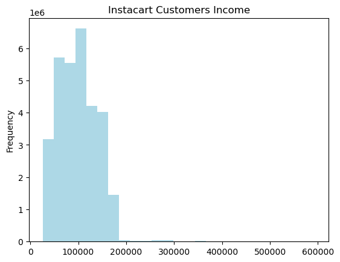

```python
# Creating an income histogram

plt.title('Instacart Customers Income'),
hist_income = df_all_2['income'].plot.hist(bins = 25, color = 'lightblue')
```

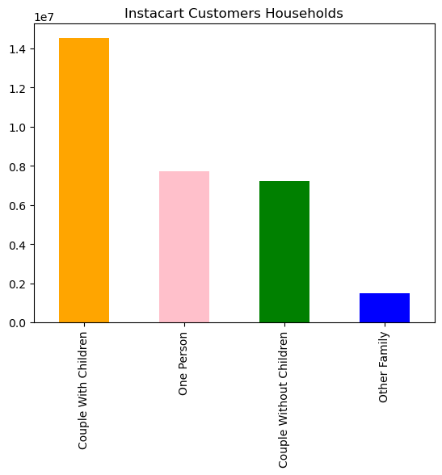

```python
# Making a household bar chart

plt.title('Instacart Customers Households'),
bar_household = df_all_2['household'].value_counts().plot.bar(color = ['orange', 'pink', 'green', 'blue'])
```

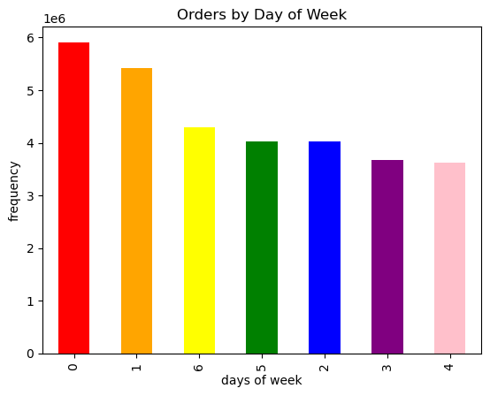

```python
# Making an orders bar chart

plt.title('Orders by Day of Week'),
bar_orders = df_all_2['orders_day_of_week'].value_counts().plot.bar(color = ['red', 'orange', 'yellow', 'green', 'blue', 'purple', 'pink'])
plt.xlabel('days of week')
plt.ylabel('frequency')
```

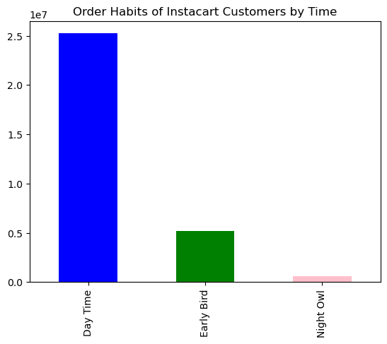

```python
# Create a bar chart of ‘time_order_habit' column

plt.title('Order Habits of Instacart Customers by Time')
time_habit_bar = df_all_2['time_order_habit'].value_counts().plot.bar(color = ['blue', 'green', 'pink'])
```

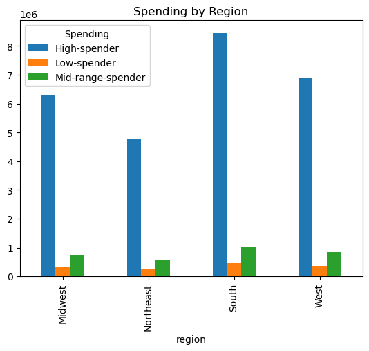

```python
# creating a barchart from the spending by region crosstab

bar_reg_spend = crosstab.plot.bar().legend(title='Spending')
plt.title ('Spending by Region')
```

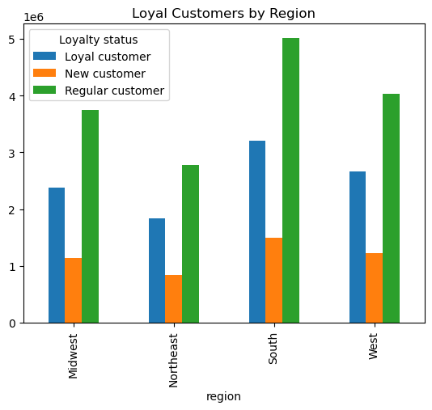

```python
# Bar chart of loyalty status by region

bar_loyalty_region = crosstab_reg_loyal.iloc[:,[0,1,2]].plot.bar().legend(title='Loyalty status')
plt.title ('Loyal Customers by Region')
```

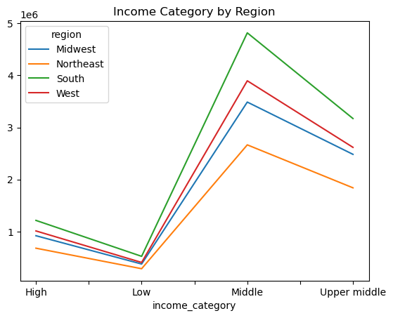

```python
# Create a chart of income by region

line_inc_reg = crosstab_income_region.plot()
plt.title('Income Category by Region')
```

## 0.6 Aggregation

### 7. Aggregate the max, mean, and min variables on a customer-profile level for usage frequency and expenditure.

```python
# Comparing the Max, Min & Mean Values

df_all_2.groupby('profile').agg({'prices': ['max', 'min', 'mean'], 'days_since_prior_order':['mean', 'min', 'max']})
```

| profile | prices max | prices min | prices mean | days_since_prior_order mean | days_since_prior_order min | days_since_prior_order max |
| --- | --- | --- | --- | --- | --- | --- |
| Alcohol Drinkers | 15.0 | 1.0 | 8.109625 | 9.990111 | 0.0 | 30.0 |
| Average-Income Family | 25.0 | 1.0 | 7.774074 | 10.818098 | 0.0 | 30.0 |
| Has babies | 15.0 | 1.0 | 7.647681 | 9.737722 | 0.0 | 30.0 |
| High-Income Family | 25.0 | 1.0 | 7.955993 | 10.807998 | 0.0 | 30.0 |
| Low-Income Family | 25.0 | 1.0 | 6.497823 | 11.260228 | 0.0 | 30.0 |
| Meat Eaters | 25.0 | 8.0 | 16.276867 | 11.112522 | 0.0 | 30.0 |
| Other | 20.0 | 1.0 | 7.601217 | 10.797818 | 0.0 | 30.0 |
| Pet Owners | 15.0 | 1.0 | 7.887489 | 11.593531 | 0.0 | 30.0 |

### 8. Compare your customer profiles with regions and departments. Can you identify a link between them? Customers may demonstrate different behaviors across regions, which could make this information important.

```python
# Comparing customer profiles & regions

crosstab_pro_reg = pd.crosstab(df_all_2['profile'], df_all_2['region'], dropna = False)
```

```python
# Comparing customer profiles & departments

crosstab_pro_dep = pd.crosstab(df_all_2['profile'], df_all_2['department_id'], dropna = False)
```

```python
crosstab_pro_reg.to_clipboard()
```

```python
crosstab_pro_dep.to_clipboard()
```

## 0.7 Crosstabs

```python
# Comparing customer order times & loyalty status

crosstab_habit_loyalty = pd.crosstab(df_all_2['time_order_habit'], df_all_2['loyalty_flag'], dropna = False)
```

```python
crosstab_habit_loyalty.to_clipboard()
```

```python
# Comparing customer order times & region

crosstab_habit_region = pd.crosstab(df_all_2['time_order_habit'], df_all_2['region'], dropna = False)
```

```python
crosstab_habit_region.to_clipboard()
```

```python
# Comparing customer order family status & order times

crosstab_habit_family = pd.crosstab(df_all_2['time_order_habit'], df_all_2['family_status'], dropna = False)
```

```python
crosstab_habit_family.to_clipboard()
```

```python
# Comparing region with loyalty flag

crosstab_reg_loyal = pd.crosstab(df_all_2['region'], df_all_2['loyalty_flag'], dropna = False)
```

```python
crosstab_reg_loyal.to_clipboard()
```

```python
# Comparing customer income & region

crosstab_income_region = pd.crosstab(df_all_2['income_category'], df_all_2['region'], dropna = False)
```

```python
crosstab_income_region.to_clipboard()
```

## 0.8 Exporting Visualizations

```python
hist_income.figure.savefig(os.path.join(path, '04 Analysis', 'Visualizations','income_histogram.png'))
```

```python
bar_household.figure.savefig(os.path.join(path, '04 Analysis', 'Visualizations','houshold_barchart.png'))
```

```python
bar_orders.figure.savefig(os.path.join(path, '04 Analysis','Visualizations', 'bar_orders_dow2.png'))
```

```python
line_inc_reg.figure.savefig(os.path.join(path, '04 Analysis', 'Visualizations','income_by_region_linechart.png'))
```

```python
bar_loyalty_region.figure.savefig(os.path.join(path, '04 Analysis', 'Visualizations','loyalty_region_barchart.png'))
```

```python
bar_reg_spend.figure.savefig(os.path.join(path, '04 Analysis', 'Visualizations', 'spending_region_barchart.png'))
```

```python
time_habit_bar.figure.savefig(os.path.join(path, '04 Analysis', 'Visualizations', 'customer_order_habits_barchart.png'))
```